# Lab 9 - Unsupervised Learning and Clustering

Cameron Wonchoba

03/31/20

# Overview

Given a dataset that describes customer purchasing patterns and behaivors, we want form clusters that describe different types of customers. Using these clustered customers, this grocery store can develop marketing campaigns and deals that appeal to these specfic types of customers.

```python
import pandas as pd
import numpy as np
```

# Data

This data set describes customer data of a grocery store distributor in Portugal.

The following variables are present in the data set:

1. `FRESH` - annual spending (m.u.) on fresh products (Continuous);
2. `MILK` - annual spending (m.u.) on milk products (Continuous);
3. `GROCERY` - annual spending (m.u.)on grocery products (Continuous);
4. `FROZEN` - annual spending (m.u.)on frozen products (Continuous)
5. `DETERGENTS_PAPER` - annual spending (m.u.) on detergents and paper products (Continuous)
6. `DELICATESSEN` - annual spending (m.u.)on and delicatessen products (Continuous);
7. `CHANNEL` - customers’ Channel - Horeca (Hotel/Restaurant/Café) (Represented as 1) or Retail channel (Represented as 2) (Nominal)
8. `REGION` - customers’ Region – Lisnon (Represented as 1), Oporto (Represented as 2) or Other (Represented as 3) (Nominal)

```python
df = pd.read_csv("Wholesale customers data.csv")
```

```python
df.head()
```

|  | Channel | Region | Fresh | Milk | Grocery | Frozen | Detergents_Paper | Delicassen |
| --- | --- | --- | --- | --- | --- | --- | --- | --- |
| 0 | 2 | 3 | 12669 | 9656 | 7561 | 214 | 2674 | 1338 |
| 1 | 2 | 3 | 7057 | 9810 | 9568 | 1762 | 3293 | 1776 |
| 2 | 2 | 3 | 6353 | 8808 | 7684 | 2405 | 3516 | 7844 |
| 3 | 1 | 3 | 13265 | 1196 | 4221 | 6404 | 507 | 1788 |
| 4 | 2 | 3 | 22615 | 5410 | 7198 | 3915 | 1777 | 5185 |

# Exploratory Data Analysis

```python
from pandas_profiling import ProfileReport
#Generating Profile Report
profile = ProfileReport(df)

#Outputing Profile Report to html file in current directory
profile
```

Report generated with pandas-profiling.

### Things to Note:

- `Detergents_Paper` and `Grocery` are highly correlated with each other.
- Most of our variables are skewed to the right heavily.
- All values are present and clean.
- Our data is not standardized. This presents a problem for distance based algorithms (such as K Means).
  - We should standardize our data to fix this issue.

```python
# standardizing the data
from sklearn.preprocessing import StandardScaler
scaler = StandardScaler()
data_scaled = scaler.fit_transform(df)

df_scaled = pd.DataFrame(data_scaled, columns = df.columns)
```

```python
#Generating Profile Report
profile = ProfileReport(df_scaled)

#Outputing Profile Report to html file in current directory
profile
```

Report generated with pandas-profiling.

Our data is now standardized, so it should be good to go.

# Models

```python
#import libraries
import pandas as pd
import numpy as np
import matplotlib.pyplot as plt
from sklearn.cluster import KMeans
```

### Build KMeans model

```python
# defining the kmeans function with initialization as k-means++
kmeans = KMeans(n_clusters=2, init='k-means++')

# fitting the k means algorithm on scaled data
kmeans.fit(data_scaled)
```

```
KMeans(algorithm='auto', copy_x=True, init='k-means++', max_iter=300,
       n_clusters=2, n_init=10, n_jobs=None, precompute_distances='auto',
       random_state=None, tol=0.0001, verbose=0)
```

### Intertia

`Inertia` will tell us how far points are from the center of the cluster. That is, it sums up all the distances of all points within a cluster to the center of that cluster.

This should intuively tell us that the smaller our Interia, the better our clustering.

```python
kmeans.inertia_
```

```
2599.38555935614
```

We have an `inertia` of ~2600 which is hard to interpret as we don't have any context for this value.

#### Building models with varying sizes of k

We will store the inertia value and plot this against the number of clusters.

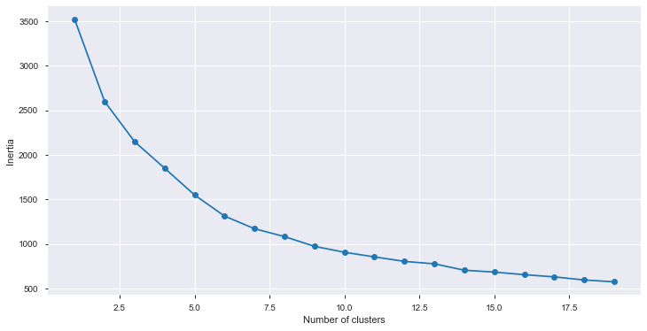

```python
# fitting multiple k-means algorithms and storing the values in an empty list
SSE = []
for cluster in range(1,20):
    kmeans = KMeans(n_jobs = -1, n_clusters = cluster, init='k-means++')
    kmeans.fit(data_scaled)
    SSE.append(kmeans.inertia_)

# converting the results into a dataframe and plotting them
frame = pd.DataFrame({'Cluster':range(1,20), 'SSE':SSE})
plt.figure(figsize=(12,6))
plt.plot(frame['Cluster'], frame['SSE'], marker='o')
plt.xlabel('Number of clusters')
plt.ylabel('Inertia')
```

Using the elbow method, we can pick clusters anywhere between 5 and 8.

We will choose 5 here.

### Build model with 5 clusters

```python
# k means using 5 clusters and k-means++ initialization
kmeans = KMeans(n_jobs = -1, n_clusters = 5, init='k-means++')
kmeans.fit(data_scaled)
pred = kmeans.predict(data_scaled)
```

#### Count the number of occurences in each cluster

```python
frame = pd.DataFrame(data_scaled)
frame['cluster'] = pred
frame['cluster'].value_counts()
```

```
3    209
1    126
0     92
2     12
4      1
Name: cluster, dtype: int64
```

## How does this solve the buisness problem?

This does not solve our buisness problem quite yet. We have our observations seperated into clusters, but we still don't know what these mean.

## Visualizing the clusters

Lets visualize these clusters to see what we can learn.

This source helped me get there: https://matplotlib.org/3.1.1/gallery/images_contours_and_fields/image_annotated_heatmap.html

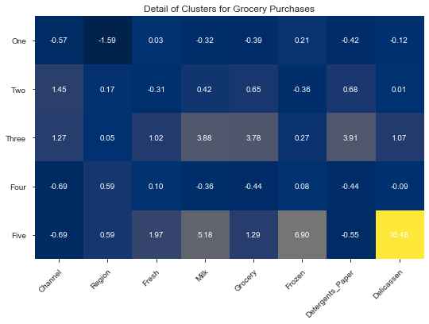

```python
cluster_centers = kmeans.cluster_centers_
cluster_names = ["One", "Two", "Three", "Four", "Five"]
variable_names = df.columns

plt.rcParams["axes.grid"] = False
fig, ax = plt.subplots()
im = ax.imshow(cluster_centers, cmap = 'cividis')

# We want to show all ticks...
ax.set_xticks(np.arange(len(variable_names)))
ax.set_yticks(np.arange(len(cluster_names)))

# ... and label them with the respective list entries
ax.set_xticklabels(variable_names)
ax.set_yticklabels(cluster_names)

# Rotate the tick labels and set their alignment.
plt.setp(ax.get_xticklabels(), rotation=45, ha="right",
         rotation_mode="anchor")

# Loop over data dimensions and create text annotations.
for i in range(len(cluster_names)):
    for j in range(len(variable_names)):
        text = ax.text(j, i, '%.2f'%cluster_centers[i, j],
                       ha="center", va="center", color="w")

ax.set_title("Detail of Clusters for Grocery Purchases")
fig.tight_layout()
plt.show()
```

### Interpreting Clusters

##### What do the numbers mean?

Smaller values mean that they purchased less of the product.

Region:

- Smaller values Lisnon (-1.99)
- Medium Values Oporto (-0.70)
- Larger Values Other (0.59)

**Cluster 1** (126 observations)

## KMeans Clustering Conclusions

We picked 5 clusters, and was able to visualize these clusters and draw some conclusions about these different clusters.

Using the results of these clusters, a buisness owner of a wholesale grocery store can now adjust their buisness plans to make these groups happier, and bring in more money to the store.

## Build DCSCAN Cluster Model

The next clustering technique we will try will be DBSCAN Clustering

```python
from sklearn.cluster import DBSCAN

db = DBSCAN().fit(data_scaled)
labels = db.labels_

# Number of clusters in labels, ignoring noise if present.
n_clusters_ = len(set(labels)) - (1 if -1 in labels else 0)
n_noise_ = list(labels).count(-1)
```

```python
print('Estimated number of clusters: %d' % n_clusters_)
print('Estimated number of noise points: %d' % n_noise_)
```

```
Estimated number of clusters: 8
Estimated number of noise points: 255
```

```python
dbscan_frame = pd.DataFrame(data_scaled)
frame['cluster'] = labels
frame['cluster'].value_counts()
```

```
-1    255
 1    130
 5     22
 4      7
 6      6
 2      5
 7      5
 3      5
 0      5
Name: cluster, dtype: int64
```

255 observations are labeled as "noise", meaning they do not belong to a cluster.

When using DBSCAN it is much more difficult to describe the clusters, and bring buisness value. Each cluster can take on a weird shape that is unique and non-circular, so computing the center of the cluster is not feasible.

## Question

Is there any way to do something similar to what I did above for KMeans? Is there a way for me to interpret the clusters of DBSCAN?

# Conclusions

KMeans was easy to use and performed well. We were able to visualize our results and bring buisness value by defining each cluster. DBSCAN was also easy to build, however because of the non-circular cluster shapes, it was much more difficult to define each cluster.

For this reason, KMeans is our preferred approach of clustering for this problem. Once we have a way to intepret DBSCAN clustering, this choice may change.

### Buisness results

Altogether, we have 5 different types of customers with different purchasing power (see the KMeans section). However, only two of these clusters bring significant value to the grocery store (ie. they make big purchases).

These two groups are:

- `Retail` channels in `varying-other` regions.
- `Horeca` channels in `other` regions.

The grocery store should develop marketing campaigns to target these places to drive up sales even more, and they should investigate why the other clusters aren't buying as many items as the two clusters.

### Final Remarks

I want to know if there are any other ways to interpret clusters (such as the approach I took for visualizing the KMeans results). Clusters seem useless to me unless we have some way to understand why clusters are made. Knowing how many clusters there seems to bring no extra (useful) knowledge.